# **Day 1: Nonprobability samples**

Author

Camilla Salvatore

# 1 **Introduction**

This material is part of the GESIS workshop “**Survey Data Integration: Combining (Non)probability, Administrative, and Digital Trace Data**”.

Click on the link to download the [data](https://drive.google.com/drive/folders/14VMsaLCK2eeGT0-W8Y8EUeP3s-tgfts1?usp=sharing).

In this practical session we learn how to do inference with nonprobability samples. It is divided into three parts:

1. Evaluation of the quality of nonprobability samples;
2. Frequentist approaches to inference;
3. Bayesian Multilevel Regression and Post-stratification (MRP).

# 2 **Quality evaluation**

In this session you will learn how to **evaluate the quality of a nonprobability sample (NPS)** by comparing it with benchmarks. We work at three levels, following Rohr, Silber and Felderer (2025):

1. **Univariate**: are the means and proportions in the sample close to the population values?
2. **Bivariate**: are the correlations between variables similar to those in the population?
3. **Multivariate**: are the coefficients of a regression model similar?

We use the R package **sampcompR** (Rohr & Felderer) for all three levels. Each part contains a **solved example**, followed by **exercises**. Try the exercises first, then click to show the solution.

**Objectives**

- Evaluate how far a nonprobability sample is from the population, and compare it with a probability sample of the same size
- Compare the results at the univariate, bivariate and multivariate level

## 2.1 **The data**

In this exercise, we use the `card` data from the `wooldridge` package. The data come from the study ‘Using Geographic Variation in College Proximity to Estimate the Return to schooling’ by Card (1995), based on survey data abou young men. It conissts of 3,010 observations, with information on education, family background, wages and test scores.

For the sake of the exercise, we treat the 3,010 men as our **population** and draw two samples from it. The few missing values in the original data (e.g. in `IQ` and in the parents’ education) were imputed beforehand, so all data sets are complete. In particular, the data we provide you with are:

1. **Population**: `pop_benchmark_quality.rda` – The whole `card` data (N = 3,010), used as benchmark.
2. **Probability Sample (PS)**: `p_sample_quality.rda` – A simple random sample of size 1,000.
3. **Non-Probability Sample (NPS)**: `nps_sample_quality.rda` – A sample of size 1,000, drawn from the men **not** in the PS, in which **younger** and **more educated** men were more likely to participate (self-selection mechanism).

We consider the following variables:

- `age` : Age in years (24–34)
- `educ` : Years of schooling
- `fatheduc`, `motheduc` : Years of schooling of the father and of the mother
- `wage` : Hourly wage in cents (`lwage` = log of wage)
- `IQ` : IQ score
- `KWW` : Score on the “knowledge of the world of work” test
- `married` : Married (1 = Yes; 0 = No)
- `black` : Black (1 = Yes; 0 = No)
- `south` : Lives in the South (1 = Yes; 0 = No)
- `smsa` : Lives in a metropolitan area (1 = Yes; 0 = No)

**Note**

- Install the packages once: `install.packages(c("sampcompR", "survey"))`
- Put the three data files in your working directory

### 2.1.1 **Preliminary analyses**

1. **Before starting, load the necessary R packages and the data:**

```r
library(sampcompR)
library(survey)

data_dir <- params$data_dir   # folder containing the .rda files
load(file.path(data_dir, "pop_benchmark_quality.rda"))
load(file.path(data_dir, "p_sample_quality.rda"))
load(file.path(data_dir, "nps_sample_quality.rda"))
```

**Task:** Familiarize yourself with the datasets.

```r
str(nps_sample_quality)
summary(pop_benchmark_quality)
```

2. **Prepare the data:** We create some additional variables in the same way in the three data sets:
- `age_cat` : 1 = 24–26; 2 = 27–29; 3 = 30–34 years, and `educ_cat` : 1 = less than 12 years; 2 = 12 years (high school); 3 = 13–15 years; 4 = 16 years or more (college). We need these categories for weighting (exercise 2 of the univariate comparison)
- `exper` : potential labour market experience in years (age − years of schooling − 6), and its square `expersq`, as in Card (1995). We need them for the multivariate comparison

```r
prep <- function(df) {
  df$age_cat  <- as.character(cut(df$age,  breaks = c(23, 26, 29, 34),    labels = 1:3))
  df$educ_cat <- as.character(cut(df$educ, breaks = c(0, 11, 12, 15, 18), labels = 1:4))
  df$exper    <- df$age - df$educ - 6
  df$expersq  <- df$exper^2
  df
}

pop <- prep(pop_benchmark_quality)
ps  <- prep(p_sample_quality)
nps <- prep(nps_sample_quality)

table(pop$educ_cat)
```

```
  1   2   3   4
497 992 704 817
```

3. **Compare the three data sets:** Compare the means of the variables in the population, the PS and the NPS. You can use `colMeans()` with `na.rm = TRUE`.

**Click here to show the solution**

```r
vars <- c("age", "educ", "fatheduc", "motheduc", "wage", "IQ", "KWW",
          "married", "black", "south", "smsa")

round(rbind(population = colMeans(pop[vars], na.rm = TRUE),
            PS         = colMeans(ps[vars],  na.rm = TRUE),
            NPS        = colMeans(nps[vars], na.rm = TRUE)), 2)
```

```
             age  educ fatheduc motheduc   wage     IQ   KWW married black
population 28.12 13.26     9.58    10.20 577.28  99.05 33.48    0.71  0.23
PS         28.15 13.16     9.52    10.09 567.32  97.83 33.32    0.71  0.26
NPS        26.81 14.46    10.52    10.94 576.04 103.60 33.71    0.66  0.19
           south smsa
population  0.40 0.71
PS          0.43 0.72
NPS         0.35 0.75
```

The men in the NPS are younger and more educated, as expected. But the NPS also differs on variables that were **not** used in the selection: for example, its respondents have more educated parents, and fewer of them are Black or married.

## 2.2 **Univariate comparison with sampcompR**

### 2.2.1 **Solved example**

`uni_compare()` compares every variable in `variables` between each sample in `dfs` and the corresponding benchmark in `benchmarks`. Both are given as **names of data frames** (strings). Here we compare both samples with the population.

**Click here to show the code (but first try it yourself!)**

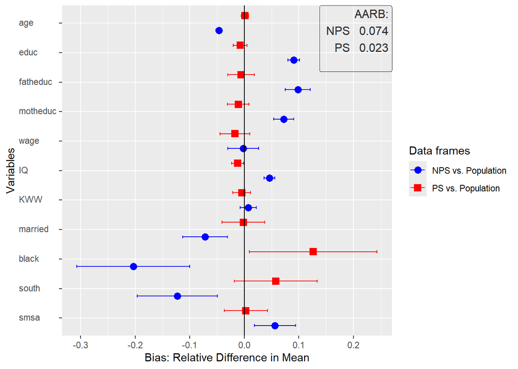

```r
uni <- uni_compare(dfs        = c("nps", "ps"),
                   benchmarks = c("pop", "pop"),
                   variables  = vars,
                   funct      = "rel_mean",   # relative difference in means
                   nboots     = 0,            # analytic CIs (quick)
                   summetric  = "avg2",       # AARB
                   data       = TRUE,
                   type       = "comparison")

plot_uni_compare(uni, name_dfs = c("NPS", "PS"),
                 name_benchmarks = c("Population", "Population"))
```

```r
uni_compare_table(uni)
```

```
      Variables       nps                ps
 [1,] "age"           "-0.047"           " 0.001"
 [2,] ""              "(-0.052, -0.041)" "(-0.006,  0.008)"
 [3,] "educ"          " 0.091"           "-0.008"
 [4,] ""              "( 0.080,  0.101)" "(-0.020,  0.005)"
 [5,] "fatheduc"      " 0.098"           "-0.006"
 [6,] ""              "( 0.075,  0.121)" "(-0.031,  0.018)"
 [7,] "motheduc"      " 0.072"           "-0.011"
 [8,] ""              "( 0.054,  0.090)" "(-0.031,  0.008)"
 [9,] "wage"          "-0.002"           "-0.017"
[10,] ""              "(-0.031,  0.026)" "(-0.044,  0.010)"
[11,] "IQ"            " 0.046"           "-0.012"
[12,] ""              "( 0.036,  0.056)" "(-0.023, -0.002)"
[13,] "KWW"           " 0.007"           "-0.005"
[14,] ""              "(-0.008,  0.022)" "(-0.021,  0.011)"
[15,] "married"       "-0.072"           "-0.002"
[16,] ""              "(-0.113, -0.031)" "(-0.041,  0.037)"
[17,] "black"         "-0.204"           " 0.126"
[18,] ""              "(-0.307, -0.100)" "( 0.009,  0.243)"
[19,] "south"         "-0.123"           " 0.058"
[20,] ""              "(-0.196, -0.050)" "(-0.018,  0.134)"
[21,] "smsa"          " 0.056"           " 0.003"
[22,] ""              "( 0.019,  0.094)" "(-0.036,  0.042)"
[23,] "Average Error" "0.074"            "0.023"
[24,] "RANK"          "2"                "1"
[25,] "N"             "1000"             "1000"
```

**How to read the output**

- Each point is the **relative bias** of a mean, $(\bar y_s - \bar y_b)/\bar y_b$, with a 95% confidence interval. Points to the right of zero are over-estimated.
- The box in the plot (and the row *Average Error* in the table) is the **AARB**, the mean of the absolute relative biases, as a proportion (0.10 = 10%): the same index as in the lecture.
- The row *RANK* orders the samples from the most to the least accurate.
- The PS also shows a few significant differences (e.g. for `black`). With 11 variables, this can happen by chance: a probability sample is unbiased **on average**, but every single sample has sampling error.

**Note**

`nboots = 0` gives analytic confidence intervals and is fast, but the package authors recommend **bootstrap** intervals for real analyses (`nboots` = 2,000 or more). Other options for the difference (`funct`) and the summary metric (`summetric`, e.g. `"rmse2"`) are described in `?uni_compare`.

### 2.2.2 **Exercises**

1. **Bootstrap and absolute differences:** Re-run the comparison with bootstrap confidence intervals (`nboots = 500`, to keep it fast). Do your conclusions change? Then try `funct = "abs_rel_mean"`: what changes in the plot?

**Click here to show the solution**

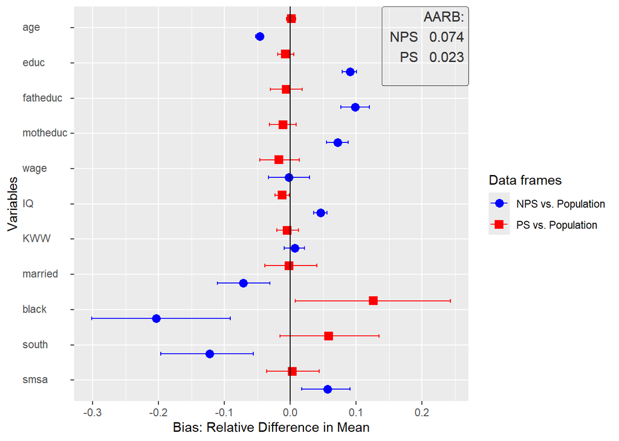

```r
set.seed(123)
uni_boot <- uni_compare(dfs = c("nps", "ps"), benchmarks = c("pop", "pop"),
                        variables = vars, funct = "rel_mean",
                        nboots = 500, summetric = "avg2", data = TRUE, type = "comparison")
plot_uni_compare(uni_boot, name_dfs = c("NPS", "PS"),
                 name_benchmarks = c("Population", "Population"))
```

The point estimates are identical; only the confidence intervals change slightly, so the conclusions do not change. With `funct = "abs_rel_mean"` all biases are shown as positive values: you lose the **direction** of the bias (over- vs under-representation), which is often the most informative part of the plot.

2. **Does weighting fix the bias?** `uni_compare()` can rake a sample before comparing it with the benchmark. Rake the NPS to the population distribution of **age groups and education groups** (`age_cat`, `educ_cat`) and compare the raked NPS with the unweighted NPS. Which biases are reduced? Why are the biases of age and education not exactly zero?

**Note**

The raking targets are a list of data frames with the categories and the population counts (`Freq`), as in `survey::rake()`. You can get them from the population with `as.data.frame(table())`.

**Click here to show the solution**

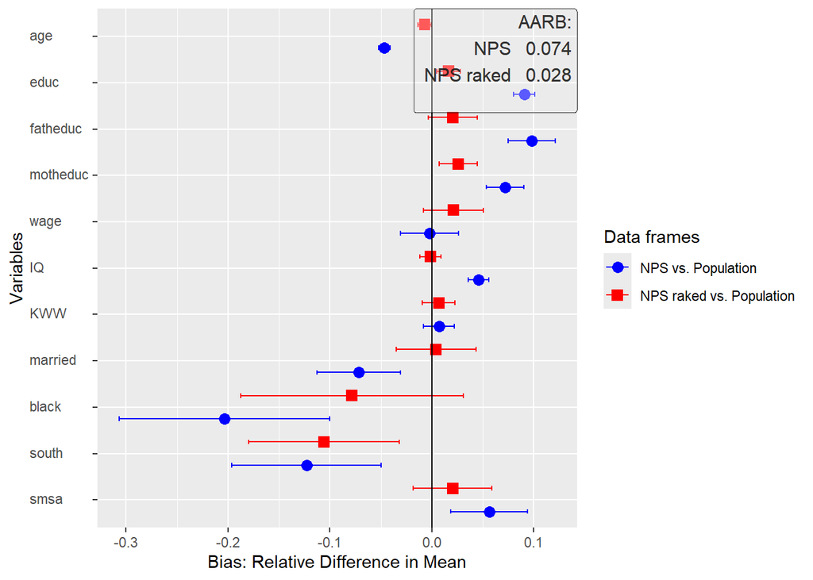

```r
targets <- function(v) {
  d <- as.data.frame(table(pop[[v]]))
  names(d) <- c(v, "Freq")
  d
}

nps_raked <- nps   # a copy, so that the two samples have different names
uni_rake <- uni_compare(dfs = c("nps", "nps_raked"), benchmarks = c("pop", "pop"),
                        variables = vars, funct = "rel_mean",
                        nboots = 0, summetric = "avg2", data = TRUE, type = "comparison",
                        id = "id", weight = "weight",
                        adjustment_weighting = "raking",
                        adjustment_vars = list(NULL, c("age_cat", "educ_cat")),
                        raking_targets  = list(NULL, list(targets("age_cat"), targets("educ_cat"))))
plot_uni_compare(uni_rake, name_dfs = c("NPS", "NPS raked"),
                 name_benchmarks = c("Population", "Population"))
```

Raking reduces most biases (the AARB falls from about 0.07 to about 0.03), also for variables that were not used in the weighting (parents’ education, IQ, `married`), because they are related to age and education. But not all: the bias of `south` hardly changes, and `wage`, which was almost unbiased, becomes slightly biased after weighting. **Weighting can also introduce bias** in some variables.

The biases of age and education are small but not exactly zero, because we raked on **groups**: within each group, the NPS is still a bit younger and more educated than the population.

Even though we know exactly which variables explain participation (age and education), raking cannot fully correct the bias because we use broad categories of these variables rather than sufficiently detailed information. In real nonprobability samples, selection also depends on variables we do not observe, and weighting removes even less of the bias.

## 2.3 **Bivariate comparison with sampcompR**

### 2.3.1 **Solved example**

`biv_compare()` compares the Pearson correlations of all pairs of variables in each sample with those in the benchmark.

**Click here to show the code (but first try it yourself!)**

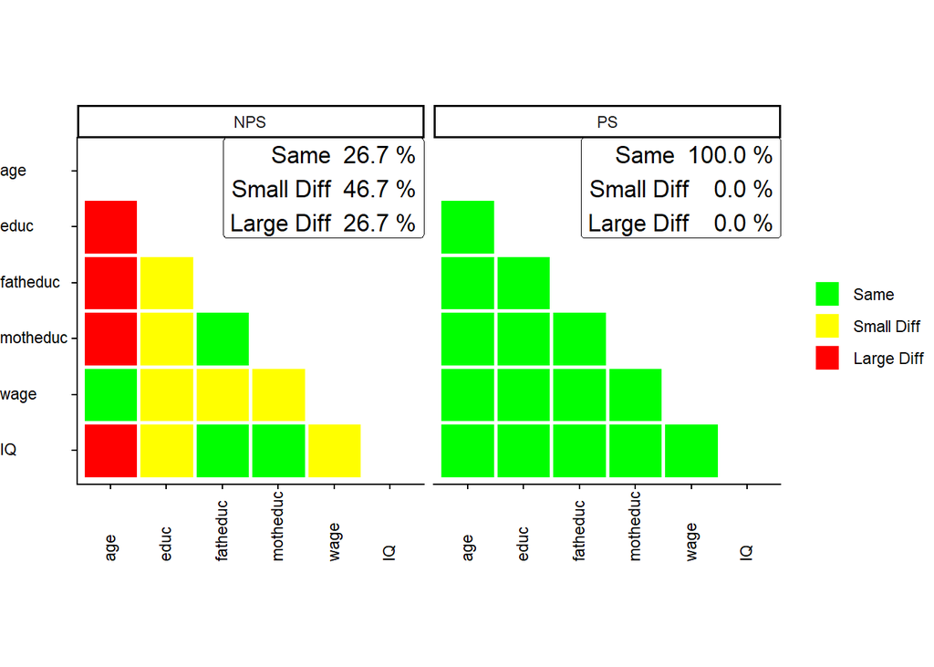

```r
biv_vars <- c("age", "educ", "fatheduc", "motheduc", "wage", "IQ")

biv <- biv_compare(dfs        = c("nps", "ps"),
                   benchmarks = c("pop", "pop"),
                   variables  = biv_vars,
                   corrtype   = "rho",      # Pearson's r
                   data       = TRUE)
plot_biv_compare(biv, plots_label = c("NPS", "PS"), missings_x = FALSE)
```

The colours classify each pair:

- **Same**: the correlations do not differ significantly (or are non-significant in both data sets);
- **Small Diff**: the correlations differ significantly;
- **Large Diff**: they differ significantly and have opposite signs, or one is at least twice as large as the other.

The percentages in the plot summarise how many correlations fall in each class. The tables show the differences and the correlation matrices of the NPS and of the population:

**Click here to show the code (but first try it yourself!)**

```r
biv_compare_table(biv, type = "diff",       comparison_number = 1)
```

```
         age        educ       fatheduc   motheduc   wage       IQ
age      ""         ""         ""         ""         ""         ""
educ     " 0.25***" ""         ""         ""         ""         ""
fatheduc " 0.12** " "-0.07*  " ""         ""         ""         ""
motheduc " 0.10** " "-0.09** " "-0.02   " ""         ""         ""
wage     " 0.05   " "-0.07*  " "-0.08*  " "-0.08*  " ""         ""
IQ       " 0.07*  " "-0.06*  " "-0.06   " "-0.05   " "-0.12***" ""
```

```r
biv_compare_table(biv, type = "dfs",        comparison_number = 1)
```

```
         age       educ      fatheduc  motheduc  wage      IQ
age      ""        ""        ""        ""        ""        ""
educ     "0.26***" ""        ""        ""        ""        ""
fatheduc "0.04   " "0.41***" ""        ""        ""        ""
motheduc "0.05   " "0.38***" "0.62***" ""        ""        ""
wage     "0.34***" "0.22***" "0.14***" "0.15***" ""        ""
IQ       "0.03   " "0.52***" "0.38***" "0.36***" "0.19***" ""
```

```r
biv_compare_table(biv, type = "benchmarks", comparison_number = 1)
```

```
         age        educ       fatheduc   motheduc   wage       IQ
age      ""         ""         ""         ""         ""         ""
educ     " 0.00   " ""         ""         ""         ""         ""
fatheduc "-0.08***" " 0.49***" ""         ""         ""         ""
motheduc "-0.05** " " 0.47***" " 0.64***" ""         ""         ""
wage     " 0.29***" " 0.29***" " 0.22***" " 0.23***" ""         ""
IQ       "-0.04*  " " 0.58***" " 0.44***" " 0.41***" " 0.31***" ""
```

### 2.3.2 **Exercises**

1. **More variables:** Repeat the bivariate comparison adding the binary variables `married`, `black` and `south` and the test score `KWW`. Do most correlations remain similar? What does this suggest about the claim that “relationships are more robust to selection bias than means”?

**Click here to show the solution**

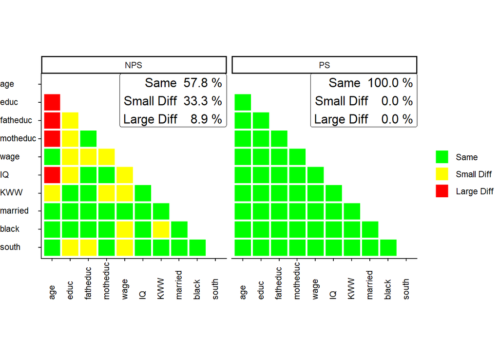

```r
biv2 <- biv_compare(dfs = c("nps", "ps"), benchmarks = c("pop", "pop"),
                    variables = c(biv_vars, "KWW", "married", "black", "south"),
                    corrtype = "rho", data = TRUE)
plot_biv_compare(biv2, plots_label = c("NPS", "PS"), missings_x = FALSE)
```

In our data, 19 of the 45 correlations differ significantly between the NPS and the population, and none between the PS and the population. About half of them involve age or education, but correlations of other variables (e.g. wage) are affected too. More than half of the correlations are similar, even though most means are biased. Whether relationships are robust depends on the **variables involved and on the selection mechanism**, which is exactly the conclusion of Rohr, Silber and Felderer (2025).

## 2.4 **Multivariate comparison with sampcompR**

### 2.4.1 **Solved example**

`multi_compare()` estimates the same regression model in the sample, in the benchmark, and in the pooled data with an interaction between each predictor and the data source. A significant interaction means that the coefficient differs between the two data sets.

We estimate a linear model (OLS) for the log wage, with age, education, IQ, race and region as predictors. As benchmark we use the **PS**: in practice we rarely have unit-level data for the whole population, and a high-quality probability sample is the usual benchmark for relationships between variables.

**Click here to show the code (but first try it yourself!)**

```r
indep <- c("age", "educ", "IQ", "black", "south")

# NPS vs PS
lwage_nps   <- multi_compare(df = nps, benchmark = ps, independent = indep,
                             dependent = "lwage", family = "ols")
```

```
Difference in coeficients between sets of respondents

      lwage
age   -1.73e-02**
educ  2.41e-02**
IQ    -1.09e-03
black -1.27e-01*
south -5.74e-02

Overall difference between nps & ps: 60% of coeficients are significant different
(*p<0.05 ; **p<0.005 ; ***p<0.001;  for t-test robust standard errors are used)
```

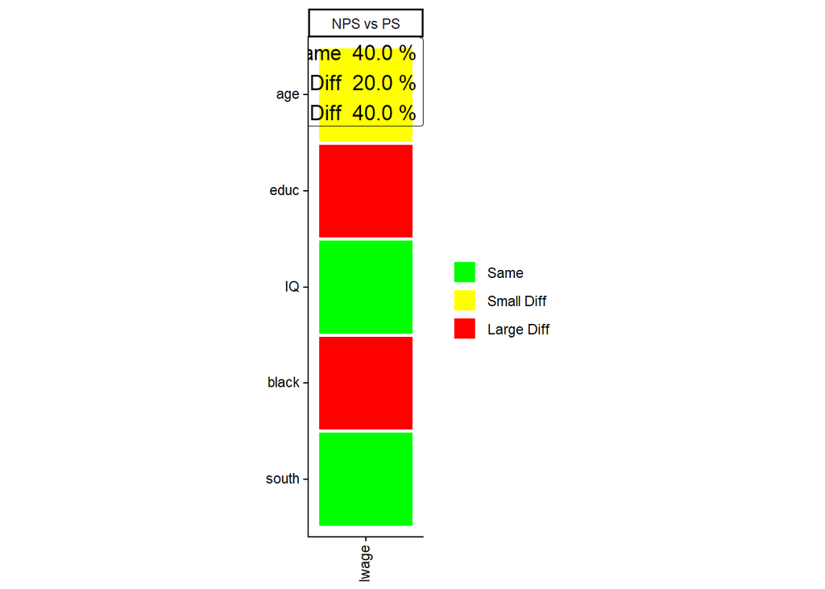

```r
plot_multi_compare("lwage_nps", plots_label = c("NPS vs PS"))
```

```r
multi_compare_table("lwage_nps", type = "diff")
```

```
      data_frames variables V3
 [1,] "nps"       "age"     "-0.017** "
 [2,] ""          ""        "(0.006)"
 [3,] ""          "educ"    "  0.024** "
 [4,] ""          ""        "(0.009)"
 [5,] ""          "IQ"      "-0.001   "
 [6,] ""          ""        "(0.001)"
 [7,] ""          "black"   "-0.127*  "
 [8,] ""          ""        "(0.05)"
 [9,] ""          "south"   "-0.057   "
[10,] ""          ""        "(0.038)"
```

Note that `plot_multi_compare()` and `multi_compare_table()` take the **names** of the objects as strings.

### 2.4.2 **Exercises**

1. **Why do the coefficients differ?** The selection into the NPS depends **only on age and education**, and both are predictors in the model. Yet several coefficients differ significantly from the PS. How can this be?

**Click here to show the solution**

If the selection depends only on the predictors **and the model is correctly specified**, the regression coefficients are not affected by the selection. But this model is only an approximation: in these data, wages depend on labour market experience in a **non-linear** way. The NPS contains mainly young, highly educated men, i.e. men with little work experience.

2. **A better model:** Estimate the wage equation used by Card (1995), with `educ`, `exper` and `expersq` instead of `age` and `educ`, plus `IQ`, `black` and `south`. Do fewer coefficients differ between the NPS and the PS?

**Click here to show the solution**

```r
lwage_nps2 <- multi_compare(df = nps, benchmark = ps,
                            independent = c("educ", "exper", "expersq", "IQ", "black", "south"),
                            dependent   = "lwage",
                            family      = "ols")
```

```
Difference in coeficients between sets of respondents

        lwage
educ    5.26e-03
exper   1.38e-02
expersq -1.13e-03
IQ      -3.40e-04
black   -1.14e-01*
south   -4.56e-02

Overall difference between nps & ps: 16.7% of coeficients are significant different
(*p<0.05 ; **p<0.005 ; ***p<0.001;  for t-test robust standard errors are used)
```

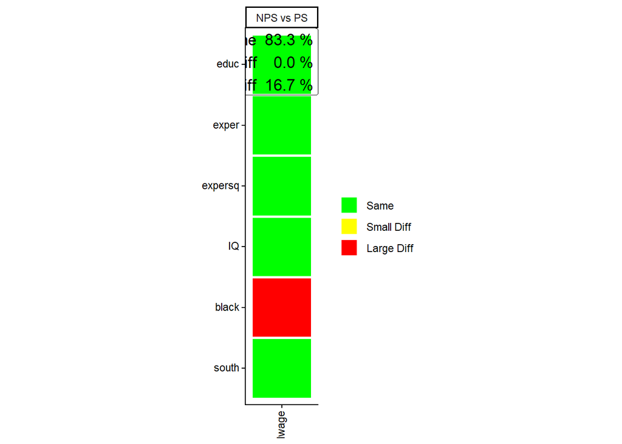

```r
plot_multi_compare("lwage_nps2", plots_label = "NPS vs PS")
```

```r
multi_compare_table("lwage_nps2", type = "diff")
```

```
      data_frames variables V3
 [1,] "nps"       "educ"    "  0.005   "
 [2,] ""          ""        "(0.01)"
 [3,] ""          "exper"   "  0.014   "
 [4,] ""          ""        "(0.019)"
 [5,] ""          "expersq" "-0.001   "
 [6,] ""          ""        "(0.001)"
 [7,] ""          "IQ"      " 0.000   "
 [8,] ""          ""        "(0.001)"
 [9,] ""          "black"   "-0.114*  "
[10,] ""          ""        "(0.05)"
[11,] ""          "south"   "-0.046   "
[12,] ""          ""        "(0.038)"
```

With a better-specified model, the coefficients of education and experience no longer differ significantly: the model describes the relationship between wage and the selection variables well, so the selection on age and education has much less effect. A difference remains for `black`.

Whether regression results from a nonprobability sample can be trusted depends on whether the variables that drive the selection are included in the model, and on whether the model is well specified. However, this might not be enough. We will see later how to deal with selection bias.

## 2.5 **Extra exercises**

1. **Other variables:** Repeat the univariate, bivariate and multivariate comparisons with other variables of the `card` data (e.g. `KWW`, `smsa`, `married`), or with other models (e.g. a logit model for `married` with `family = "logit"`).
2. **Your own data:** Apply the same comparisons to your own data: a nonprobability sample (or any sample you want to evaluate) and a benchmark, such as census figures, register data or a high-quality probability survey. Which variables can you compare? At which levels?

## 2.6 **Key take-aways**

**Key take-aways**

- Compare the NPS with the PS or with a population benchmark at three levels: **univariate**, **bivariate** and **multivariate**.
- Selection into the NPS can depend on variables we collect or on unobservable variables (the NMAR case, which we cannot test in practice).
- Bias in means does not automatically imply bias in relationships, and vice versa: check all three levels.
- Regression coefficients are more robust when the selection depends only on the predictors of a **well-specified** model; they can be biased when the model is misspecified or when variables that drive the selection are left out.

## 2.7 **References**

- Card, D. (1995). Using geographic variation in college proximity to estimate the return to schooling. In L. N. Christophides, E. K. Grant & R. Swidinsky (Eds.), *Aspects of Labour Market Behaviour: Essays in Honour of John Vanderkamp* (pp. 201–222). University of Toronto Press.
- Rohr, B., Silber, H., & Felderer, B. (2025). Comparing the accuracy of univariate, bivariate, and multivariate estimates across probability and nonprobability surveys with population benchmarks. *Sociological Methodology*, 55(1), 121–154. https://doi.org/10.1177/00811750241280963
- Rohr, B., & Felderer, B. sampcompR: Comparing and visualizing differences between surveys. R package. https://bjoernrohr.github.io/sampcompR/
- Rohr, B. sampcompR tutorial, KODAQS Toolbox (GESIS). https://kodaqs-toolbox.gesis.org/github.com/BjoernRohr/KODAQS-Toolbox-SampcompR/Tool_SampcompR/

# 3 **Frequentist approaches**

In these exercises we use the `nonprobsvy` package developed by Maciej Beręsewicz and Łukasz Chrostowski. You can find additional information about the package here:

- [Basic use cases of the nonprobsvy package](https://htmlpreview.github.io/?https://github.com/ncn-foreigners/software-tutorials/main/notebooks/2023-nonprobsvy-basic-usecases.html);
- [Modern inference methods for non-probability samples with R](https://ncn-foreigners.github.io/nonprobsvy-book/);
- GitHub [repository](https://github.com/BERENZ/nonprobsvy);
- A video of a [workshop](https://www.youtube.com/watch?v=ZcOzGK6jhSg) on nonprobsvy.

## 3.1 **The data**

In this exercise, we will analyze data from the 2003 U.S. Michigan Behavioral Risk Factor Surveillance Survey, available in the `PracTools` package. The dataset, named `mibrfss`, includes various demographic and health-related variables. We use this dataset as the basis in order to simulate a population of size `100000` and different sampling scenarios. In particular, the data we provide you with are:

1. **Population Totals**: `pop_tot.rda` – Contains population totals.
2. **Probability Sample (PS)**: `p_sample.rda` – A high-quality sample of size 10,000, assumed to be a simple random sample.
3. **Non-Probability Sample (NPS)**: `np_sample.rda` – A sample of size 1,000 with self-selection and coverage issues.

We consider a subset of the variables available in the `mibrfss` dataset, namely:

- `SMOKE100` : Smoked 100 or more cigarettes in lifetime (1 = Yes; 2 = No)
- `AGECAT` : Age group (1 = 18-24 years; 2 = 25-34 years; 3 = 35-44 years; 4 = 45-54 years; 5 = 55-64 years; 6 = 65+)
- `INETHOME` : Has access to the Internet at home (1 = Yes; 2 = No)
- `EDCAT` : Education level (1 = Did not graduate high school; 2 = Graduated high school; 3 = Attended college or technical school; 4 = Graduated from college or technical school)

For this exercise, we assume that the non-probability sample (NPS) was collected through social media advertisements. This approach introduces potential biases because only individuals with internet access and who are active on the specific social media platform could participate. Consequently, the NPS may suffer from both self-selection bias and coverage bias (since the sample is restricted to those with internet access and a presence on social media).

In contrast, we assume that the probability sample (PS) was obtained through a simple random sampling method. This sample is considered a high-quality reference sample, and for simplicity, we do not need to account for any design or calibration weights.

**Objectives**

- Estimate the proportion of U.S. individuals aged 18+ who smoked 100 or more cigarettes in their lifetime
- Compare different estimation techniques against the true population value of 52.85%

### 3.1.1 **Preliminary analyses**

1. **Before starting, load the necessary R packages:**

```r
library(tidyverse)
library(ggplot2)
library(survey)
library(nonprobsvy)
library(PracTools)
```

2. **Import and prepare the data:** Load the datasets and inspect the data. Pay attention to the data format.

```r
load("p_sample.rda")
load("np_sample.rda")
load("pop_tot.rda")
```

**Task:** Familiarize yourself with the datasets.

**Note**

- The PS survey does not contain the target variable of interest, i.e., `SMOKE100`
- You might encounter some issues when the variables are categorical. I suggest saving binary variables as numeric and variables with more than one level as character.
- Pay attention to the `pop_tot` structure. It contains the population totals and it is formatted in order to match the `nonprobsvy` and `survey` package naming terminology. The `(Intercept)` simply contains the size of the population.

```r
pop_tot
```

```
(Intercept)     AGECAT2     AGECAT3     AGECAT4     AGECAT5     AGECAT6
     100000       13408       19554       22526       16875       21879
   RACECAT2    RACECAT3      EDCAT2      EDCAT3      EDCAT4   INETHOME1
       8255        5113       30925       28464       31668       65370
```

3. **Compare the distribution of the covariates in the probability and nonprobability samples:**

   You can use `prop.table`.

**Click here to show the solution**

```r
# Age
prop.table(table(p_sample$AGECAT))
```

```
     1      2      3      4      5      6
0.0564 0.1351 0.1992 0.2211 0.1718 0.2164
```

```r
prop.table(table(np_sample$AGECAT))
```

```
    1     2     3     4     5     6
0.126 0.143 0.219 0.241 0.152 0.119
```

```r
# Race
prop.table(table(p_sample$RACECAT))
```

```
     1      2      3
0.8699 0.0792 0.0509
```

```r
prop.table(table(np_sample$RACECAT))
```

```
    1     2     3
0.878 0.061 0.061
```

```r
# Education
prop.table(table(p_sample$EDCAT))
```

```
     1      2      3      4
0.0875 0.3109 0.2801 0.3215
```

```r
prop.table(table(np_sample$EDCAT))
```

```
    1     2     3     4
0.111 0.256 0.267 0.366
```

```r
# Internet at home
prop.table(table(p_sample$INETHOME))
```

```
   0    1
0.35 0.65
```

```r
prop.table(table(np_sample$INETHOME))
```

```
   0    1
0.04 0.96
```

Individuals in the nonprobability sample are younger, more often graduated from college or technical school, and mostly have internet at home.

4. **Define the sampling design:** Specify the sampling designs for both the PS and NPS samples using the `svydesign` function.

**Click here to show the solution**

```r
ps_design <- svydesign(ids = ~ 1,data = p_sample)
nps_design <- svydesign(ids = ~ 1,data = np_sample)
```

5. **Estimate the proportion from the non-probability sample:**

Use the `svymean` and/or `svyciprop` functions to calculate the proportion and its confidence interval. Save it in a `compare` tibble where you will add the estimates obtained with different methods.

**Click here to show the solution**

```r
svymean(~ SMOKE100, nps_design)
```

```
          mean     SE
SMOKE100 0.489 0.0158
```

```r
np_est=svyciprop(~ SMOKE100, nps_design)
np_est
```

```
                2.5% 97.5%
SMOKE100 0.489 0.458 0.520
```

```r
ci=confint(svyciprop(~ SMOKE100, nps_design))
compare = tibble(estimate=np_est[1],
                lower_bound=ci[1],
                upper_bound=ci[2],
                method="nps")
```

The estimate of the proportion of individuals who smoked 100 or more cigarettes in their lifetime from the non-probability sample (NPS) is 48.9%, with a 95% confidence interval ranging from 45.8% to 52.0%. Note that the confidence interval does not include the true population proportion.

To improve our estimate, we will apply and compare various estimation techniques.

## 3.2 **Classic approaches to weighting**

In this part we will apply two standard approaches: raking and calibration.

1. Start with raking. Follow the code in the slides and include the following variables `AGECAT`, `RACECAT`, `EDCAT`, and `INETHOME`

**Click here to show the solution**

```r
rake.dsgn <- calibrate(design = nps_design,
                        formula = ~ AGECAT + RACECAT + EDCAT + INETHOME,
                        calfun = "raking",
                        population = pop_tot)
```

2. Now implement GREG. Consider the same variables as before

**Click here to show the solution**

```r
greg.dsgn <- calibrate(design = nps_design,
                        formula = ~ AGECAT + RACECAT + EDCAT + INETHOME,
                        calfun = "linear",
                        population = pop_tot)

#some weights are negative, we trim them
greg.dsgn<-trimWeights(greg.dsgn,lower=0, upper=Inf)
```

3. Save the estimates and the confidence intervals that you obtain

**Click here to show the solution**

```r
np_rake=svyciprop(~ SMOKE100, rake.dsgn)
np_rake
```

```
                2.5% 97.5%
SMOKE100 0.545 0.491 0.597
```

```r
ci=confint(svyciprop(~ SMOKE100, rake.dsgn))


compare <- compare %>%
  bind_rows(tibble(estimate=np_rake[1],
                lower_bound=ci[1],
                upper_bound=ci[2],
                method="raking"))


np_greg=svyciprop(~ SMOKE100, greg.dsgn)
np_greg
```

```
                2.5% 97.5%
SMOKE100 0.528 0.474 0.582
```

```r
ci=confint(svyciprop(~ SMOKE100, greg.dsgn))


compare <- compare %>%
  bind_rows(tibble(estimate=np_greg[1],
                lower_bound=ci[1],
                upper_bound=ci[2],
                method="greg"))
```

## 3.3 **Inverse-probability weighting**

### 3.3.1 **When a probability sample is available**

First, we assume that we have access to high-quality data from a reference probability sample. Implement IPW using the `nonprob` function with the following specifications:

1. Set up a selection model that includes the variables `AGECAT`, `RACECAT`, `EDCAT`, and `INETHOME`
2. Use as `target` variable `SMOKE100`
3. Use the probability sample design you created before as input for `svydesign`
4. Use logistic regression in `method_selection`
5. Save the estimate and the confidence interval

**Click here to show the solution**

```r
ipw_logit_ps <-
  nonprob(
    selection = ~ as.factor(AGECAT) + as.factor(RACECAT) + as.factor(EDCAT) + as.factor(INETHOME),
    target = ~ SMOKE100,
    data = np_sample,
    svydesign  = ps_design,
    method_selection = "logit"
  )

#display
cbind(ipw_logit_ps$output, ipw_logit_ps$confidence_interval)
```

```
              mean         SE lower_bound upper_bound
SMOKE100 0.5956634 0.08545015   0.4281842   0.7631426
```

```r
#save
compare <- compare %>%
  bind_rows(tibble(estimate=ipw_logit_ps$output$mean,
                lower_bound=ipw_logit_ps$confidence_interval$lower_bound,
                upper_bound=ipw_logit_ps$confidence_interval$upper_bound,
                method="ipw_ps"))
```

### 3.3.2 **When only population information is available**

Now we assume that only population totals are available.

1. Implement IPW using the `nonprob` function with the previous specifications but instead of `svydesign`, specify the `pop_totals`.

**Click here to show the solution**

```r
ipw_logit_poptotals <-
  nonprob(
  selection =  ~ AGECAT + RACECAT + EDCAT + INETHOME,
  target = ~ SMOKE100,
  data = np_sample,
  pop_totals = pop_tot,
  method_selection = "logit"
  )

#display
cbind(ipw_logit_poptotals$output, ipw_logit_poptotals$confidence_interval)
```

```
              mean         SE lower_bound upper_bound
SMOKE100 0.5449075 0.07954355    0.389005     0.70081
```

```r
#save
compare <- compare %>%
  bind_rows(tibble(
    estimate = ipw_logit_poptotals$output$mean,
    lower_bound = ipw_logit_poptotals$confidence_interval$lower_bound,
    upper_bound = ipw_logit_poptotals$confidence_interval$upper_bound,
    method = "ipw_pop_tot"
  ))
```

Now, the estimate is 54.49% but the confidence interval is quite large (CI: 38.9% - 70%). This wide interval suggests considerable uncertainty in the estimate.

## 3.4 **Mass Imputation**

### 3.4.1 **When a probability sample is available**

First, we assume that we have access to high-quality data from a reference probability sample. Implement Mass Imputation using the `nonprob` function with the following specifications:

1. Set up an outcome model for `SMOKE100` that includes the variables `AGECAT`, `RACECAT`, `EDCAT`, and `INETHOME`
2. Use the probability sample design you created before as input for `svydesign`
3. Given the outcome type, select the correct option for the `method_outcome` and `family_outcome`
4. Save the estimate and the confidence interval

**Click here to show the solution**

```r
mi_sample <- nonprob(outcome = SMOKE100 ~ AGECAT + RACECAT + EDCAT + INETHOME,
                        data = np_sample,
                     svydesign = ps_design,
                     method_outcome = "glm",
                     family_outcome = "binomial")

#display
cbind(mi_sample$output, mi_sample$confidence_interval)
```

```
              mean         SE lower_bound upper_bound
SMOKE100 0.5284922 0.02853385   0.4725669   0.5844175
```

```r
#save
compare <- compare %>%
  bind_rows(tibble(
    estimate = mi_sample$output$mean,
    lower_bound = mi_sample$confidence_interval$lower_bound,
    upper_bound = mi_sample$confidence_interval$upper_bound,
    method = "mi_sample"
  ))
```

### 3.4.2 **When only population information is available**

Now we assume that only population totals are available.

1. Implement Mass Imputation using the `nonprob` function with the previous specifications but instead of `svydesign`, specify the `pop_totals`.

**Click here to show the solution**

```r
mi_poptotals <- nonprob(outcome = SMOKE100 ~ AGECAT + RACECAT + EDCAT + INETHOME,
                        data = np_sample,
                        pop_totals = pop_tot,
                        method_outcome = "glm",
                        family_outcome = "binomial")

#display
cbind(mi_poptotals$output,mi_poptotals$confidence_interval)
```

```
              mean         SE lower_bound upper_bound
SMOKE100 0.5303919 0.03275618   0.4661909   0.5945928
```

```r
#save
compare <- compare %>%
  bind_rows(tibble(
    estimate = mi_poptotals$output$mean,
    lower_bound = mi_poptotals$confidence_interval$lower_bound,
    upper_bound = mi_poptotals$confidence_interval$upper_bound,
    method = "mi_pop_tot"
  ))
```

The estimate is 53.04% (CI: 46.6% - 59.5%).

## 3.5 **Doubly-robust inference**

### 3.5.1 **When a probability sample is available**

First, we assume that we have access to high-quality data from a reference probability sample. Implement the Doubly-robust method using the `nonprob` function with the following specifications:

1. Set up an outcome model for `SMOKE100` that includes the variables `AGECAT`, `RACECAT`, `EDCAT`, and `INETHOME`
2. Set up a selection model that includes the variables `AGECAT`, `RACECAT`, `EDCAT`, and `INETHOME`
3. Use the probability sample design you created before as input for `svydesign`
4. Given the outcome type, select the correct option for the `method_outcome` and `family_outcome`
5. Use a logistic regression for the selection model
6. Save the estimate and the confidence interval

**Click here to show the solution**

```r
dr_logit_sample <-
  nonprob(
    selection = ~ AGECAT + RACECAT + EDCAT + INETHOME,
    outcome = SMOKE100 ~ AGECAT + RACECAT + EDCAT + INETHOME,
    data = np_sample,
    svydesign = ps_design,
    method_selection = "logit",
    method_outcome = "glm",
    family_outcome = "binomial"
  )


#display
cbind(dr_logit_sample$output, dr_logit_sample$confidence_interval)
```

```
              mean         SE lower_bound upper_bound
SMOKE100 0.5261057 0.09657046    0.336831   0.7153803
```

```r
#save
compare <- compare %>%
  bind_rows(tibble(
    estimate = dr_logit_sample$output$mean,
    lower_bound = dr_logit_sample$confidence_interval$lower_bound,
    upper_bound = dr_logit_sample$confidence_interval$upper_bound,
    method = "dr_logit_sample"
  ))
```

### 3.5.2 **When only population information is available**

Now we assume that only population totals are available.

1. Implement the Doubly-Robust approach again using the `nonprob` function with the previous specifications but instead of `svydesign`, specify the `pop_totals`.

**Click here to show the solution**

```r
dr_logit_poptotals  <-
  nonprob(
    selection = ~  AGECAT + RACECAT + EDCAT + INETHOME,
    outcome = SMOKE100 ~ AGECAT + RACECAT + EDCAT + INETHOME,
    data = np_sample,
    pop_totals = pop_tot,
    method_selection = "logit",
    method_outcome = "glm",
    family_outcome = "binomial"
  )

#display
cbind(dr_logit_poptotals $output, dr_logit_poptotals $confidence_interval)
```

```
              mean         SE lower_bound upper_bound
SMOKE100 0.5467979 0.02724855   0.4933917   0.6002041
```

```r
#save
compare <- compare %>%
  bind_rows(tibble(
    estimate = dr_logit_poptotals $output$mean,
    lower_bound = dr_logit_poptotals $confidence_interval$lower_bound,
    upper_bound = dr_logit_poptotals $confidence_interval$upper_bound,
    method = "dr_logit_poptotals"
  ))
```

The estimate is 54.7% (CI: 49.3% - 60.0%).

## 3.6 **Comparing the results**

Finally, compare the estimates. You can use `ggplot` to plot the data in the `compare` table.

**Click here to show the solution**

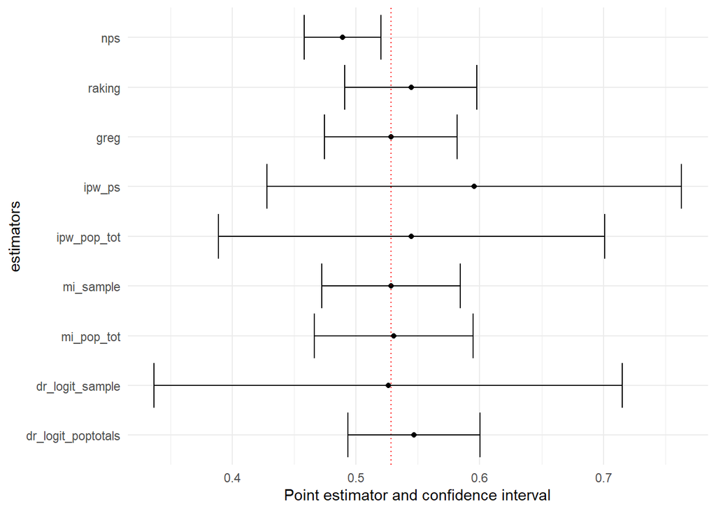

```r
compare$method=factor(compare$method, levels = c("dr_logit_poptotals","dr_logit_sample","mi_pop_tot","mi_sample","ipw_pop_tot", "ipw_ps", "greg", "raking","nps"))
compare %>%
ggplot(aes(
  y = method,
  x = estimate,
  xmin = lower_bound,
  xmax = upper_bound
)) +
  geom_point() +
  geom_vline(
    xintercept = 0.5285,
    linetype = "dotted",
    color = "red"
  ) +
  geom_errorbar() +
  labs(x = "Point estimator and confidence interval", y = "estimators")+theme_minimal()
```

# 4 **Bayesian approaches**

## 4.1 **Multilevel regression and post-stratification**

We use data from the 2018 Cooperative Congressional Election Study, a US nationwide survey designed by a consortium of 60 research teams and administered by YouGov. The data and the guide with information about the survey and the questionnaire are available [here](https://dataverse.harvard.edu/dataset.xhtml?persistentId=doi:10.7910/DVN/ZSBZ7K).

This tutorial is adapted from the book **MRP Case Studies** that you can find [here](https://bookdown.org/jl5522/MRP-case-studies/introduction-to-mister-p.html).

**Objectives**

- Estimate the proportion of individuals who support the cut in the Corporate Income Tax rate. The questionnaire item is the following:

*Congress considered many changes in tax law over the past two years. Do you support or oppose each of the following?*

**CC18_325a** **Taxes** – Cut the Corporate Income Tax rate from 39 percent to 21 percent. (Support/Oppose)

- Compare the estimates obtained with the unadjusted nonprobability sample, with the estimates we would obtain if we had a large probability sample and the estimates obtained with MRP

### 4.1.1 **The data**

The variables are the following:

- `state` : 50 US states
- `age` : Age in classes, 18-29, 30-39, 40-49, 50-59, 60-69, 70+
- `male` : Gender classified as male (1) or female (2)
- `eth` : Ethnicity classified as (Non-hispanic) White, Black, Hispanic, Other (which also includes Mixed)
- `educ` : Education classified as No HS, HS, Some college, 4-year college, Post-grad
- `region` : Geographical region classified in Northeast, North Central, South, and West
- `repvote` : Republican vote share in the 2016 presidential election

If you follow the book example, some data pre-processing is needed. Here, for simplicity, we use a ready-to-use version of the data.

Before starting, you need to install and load the following packages:

```r
library(tidyverse)
library(rstan)
library(rstanarm)
library(dplyr)
library(readr)

library(ggplot2)
library(bayesplot)
#library(ggalt)
library(reshape2)
```

You have the following datasets available:

- `statelevel_predictors_df` : contains the `repvote` and the `region` for each of the 50 US states
- `cces_biased_df` : a nonprobability sample of size 5,000 from which we obtain un-adjusted estimates and then MRP estimates
- `cces_all_df` : is the full probability sample of 59,693 observations that we use only for comparison
- `poststrat_df_full` : is the poststratification table with population counts constructed considering the state, the ethnicity, the gender, the age and the education of individuals. As we defined the levels for these variables, the poststratification table must have $50 \cdot 6 \cdot 2 \cdot 4 \cdot 5 = 12{,}000$ rows. This means we actually have more rows in the poststratification table than observed units, which necessarily implies that there are some combinations in the poststratification table that we don’t observe in our nonprobability sample. In this example, we ensured that all cells in the poststratification table were included, even if their weight was zero, but this was done solely for illustrative purposes.

```r
statelevel_predictors_df <- read_csv('statelevel_predictors.csv')
load("cces_all_df.rda")
load("cces_biased_df.rda")
load("poststrat_df_full.rda")
```

### 4.1.2 **Preliminary analyses**

1. Compare the composition of the nonprobability sample with respect to the population characteristics (in the poststratification table)

One of the possible solutions follows.

**Click here to show the solution**

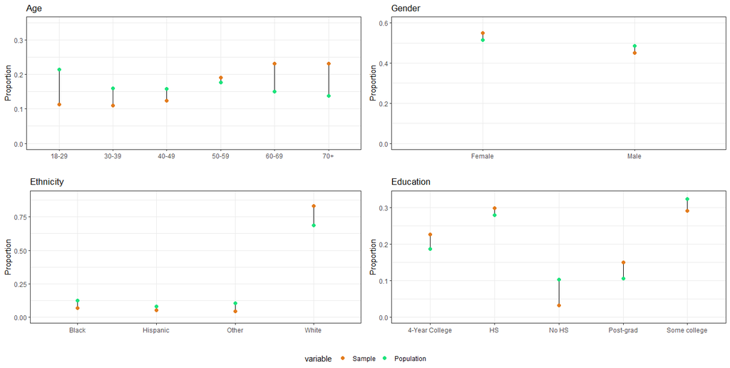

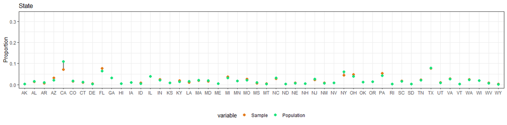

```r
library(dplyr)
library(ggplot2)
#library(ggalt)
library(reshape2)
library(forcats)

# Function to calculate sample and population proportions
calculate_proportions <- function(sample_df, poststrat_df, group_var) {
  sample_prop <- sample_df %>%
    group_by({{ group_var }}) %>%
    summarise(Sample = n() / nrow(sample_df))

  pop_prop <- poststrat_df %>%
    group_by({{ group_var }}) %>%
    summarise(Population = sum(n) / sum(poststrat_df$n))

  inner_join(sample_prop, pop_prop, by = as.character(substitute(group_var)))
}

# Function to create dumbbell plots
create_dumbbell_plot <- function(data, group_var, x_limits, title, x_label = "Proportion") {
  ggplot(data) +
    geom_dumbbell(aes(y = {{ group_var }}, x = Sample, xend = Population)) +
    geom_point(
      data = melt(data, id.vars = as.character(substitute(group_var))),
      aes(y = {{ group_var }}, x = value, color = variable),
      size = 2
    ) +
    coord_flip() +
    scale_x_continuous(limits = x_limits) +
    theme_bw() +
    labs(title = title, x = x_label, y = "") +
    theme(legend.position = "none")+
  scale_color_manual(values=c("#E37B1C", "#1CE37B"))
}




# Age Plot
age <- calculate_proportions(cces_biased_df %>% mutate(age = factor(age)), poststrat_df, age)
age_plot <- create_dumbbell_plot(age, age, c(0, 0.35), "Age", "Proportion")

# Gender Plot
gender <- calculate_proportions(cces_biased_df, poststrat_df, male) %>%
  mutate(male = factor(male, levels = c(-0.5, 0.5), labels = c("Female", "Male")))
gender_plot <- create_dumbbell_plot(gender, male, c(0, 0.6), "Gender")

# Ethnicity Plot
ethnicity <- calculate_proportions(cces_biased_df, poststrat_df, eth)
ethnicity_plot <- create_dumbbell_plot(ethnicity, eth, c(0, 0.9), "Ethnicity")

# Education Plot
education <- calculate_proportions(cces_biased_df %>% mutate(educ = factor(educ)), poststrat_df, educ)

education_plot <- create_dumbbell_plot(education, educ, c(0, 0.33), "Education")

# State Plot
state <- calculate_proportions(cces_biased_df, poststrat_df, state)

state_plot <- create_dumbbell_plot(state, state, c(0, 0.33), "State")+
  theme(legend.position="bottom")


# Display all plots

ggpubr::ggarrange(age_plot, gender_plot, ethnicity_plot,
                  education_plot, nrow=2,ncol=2,common.legend = TRUE, legend="bottom")



state_plot
```

### 4.1.3 **The Mister: MR**

1. In this section you need to implement a multilevel regression in order to predict the outcome (`taxred`) based on a set of factors.
2. Use the `stan_glmer` function.
3. Include in the model varying intercepts `(1 | x)` for: `age`, `eth`, `educ`, and `state`
4. Include interactions `(1 | x1:x2)` between `male` and `eth` , `educ` and `age` and `educ` and `eth`
5. Include as state-level predictors also `repvote` and `region`
6. Use a logistic model

**Click here to show the solution**

```r
library(rstanarm)
fit <- stan_glmer(taxred ~ (1 | state) + (1 | eth) + (1 | educ) + (1 | age) + male +
                    (1 | male:eth) + (1 | educ:age) + (1 | educ:eth) +
                    repvote + factor(region),
                  family = binomial(link = "logit"),
                  data = cces_biased_df,
                  prior = normal(0, 1, autoscale = TRUE),
                  prior_covariance = decov(scale = 0.50),
                  adapt_delta = 0.99,
                  refresh = 0,
                  seed = 1010)
```

Running this code might be computationally expensive, so you can directly load the results:

```r
fit <- readRDS("my_fit.rds")
library(Matrix)
```

### 4.1.4 **The P: Poststratification**

The second step is to poststratify, but first we use our model to get an estimate for each row of the post-stratification table. Then, poststratification is implemented by weighting the estimate by the proportion of individuals in that poststratification cell.

Thus, we first compute the proportion for each cell of the poststratification table:

```r
poststrat_df <-poststrat_df %>%
  mutate(prop=n/sum(n),.by=state)
```

The following code shows how to:

1. **Generate predictions using the Bayesian Model:**

   The first part of the code involves generating predictions for the poststratification data based on the Bayesian model we’ve estimated. This process uses the add_epred_draws() function to draw 4000 samples from the posterior predictive distribution.
2. **Compute the MRP estimates:** The procedure involves the following steps:
- *Compute the Weighted Average Prediction:* To obtain the MRP estimates, remember the formula in the slides: `pred * n/N`, where `pred` represents the predicted preference value, `n` is the number of people in each poststratification cell, and `N` is the total population size. This formula adjusts the predictions according to the size of each poststratification cell, giving a weighted average.
- *Summarize Predictions by State:* For each state, aggregate the weighted predictions from all poststratification cells within that state. At this stage, you will have 4000 weighted predictions for each state.
- *Average the Predictions across the 4000 draws:* Since we have 4000 draws, we compute the average prediction. To quantify the uncertainty, we calculate the 2.5th and 97.5th percentiles of the predictions, which form the lower and upper bounds of the 95% credibility interval, respectively.

**Click here to show the code**

```r
library(tidybayes)

mrp_estimates = fit %>%
  add_epred_draws(newdata = poststrat_df, ndraws = 4000) %>%
   rename(pred = .epred)  %>%
  mutate(ps_pred = pred * prop) %>%
  ungroup() %>%
  summarise(pred = sum(ps_pred),
            .by = c(state, .draw)) %>%
  summarise(
    estimate = mean(pred),
    lower_ci = quantile(pred, 0.025),
    upper_ci = quantile(pred, 0.975),
    .by = state
  )
```

3. **We want to compare** the MRP estimates with those derived from an unadjusted nonprobability sample and with estimates from a large probability sample. To accomplish this, you can use the following code. Remember that:
- To compute the confidence interval, you first need to determine the standard deviation of the variable (Bernoulli).
- The confidence interval is then computed as the estimate plus or minus 2 times the standard deviation. This is because, under the assumption of a normal distribution, approximately 95% of the data lies within 2 standard deviations of the mean.

**Click here to show the code**

```r
# Function to calculate the standard error for a Bernoulli distribution
get_se_bernoulli <- function(p, n) {
  sqrt(p * (1 - p) / n)
}

# Define the states
state_abb <- datasets::state.abb

# Function to calculate estimates and confidence intervals for a given dataset
calculate_estimates <- function(data, state_abb) {
  data %>%
    filter(state %in% state_abb) %>%
    group_by(state) %>%
    summarize(
      estimate = mean(taxred, na.rm = TRUE),
      n_sample = n(),
      se = get_se_bernoulli(estimate, n_sample),
      lower_ci = estimate - 2 * se,
      upper_ci = estimate + 2 * se
    ) %>%
    ungroup()
}

# Calculate estimates and confidence intervals for both datasets
biased_estimates <- calculate_estimates(cces_biased_df, state_abb)
full_estimates <- calculate_estimates(cces_all_df, state_abb)

# Combine the results into one dataset (in wide format)
states_df <- biased_estimates %>%
  rename_with(~ paste0("biased_", .), -state) %>%
  left_join(full_estimates %>%
              rename_with(~ paste0("full_", .), -state), by = "state") %>%
  left_join(mrp_estimates%>%
              rename_with(~ paste0("mrp_", .), -state), by = "state")
```

### 4.1.5 **Compare the results**

1. Compare the results using `ggplot`

**Click here to show the solution**

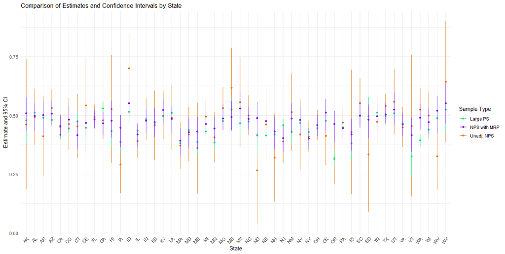

```r
# Plotting the comparison using ggplot
ggplot(states_df) +
  geom_point(aes(x = state, y = biased_estimate, color = "Unadj. NPS")) +
  geom_errorbar(aes(x = state, ymin = biased_lower_ci, ymax = biased_upper_ci, color = "Unadj. NPS"), width = 0) +
geom_point(aes(x = state, y = full_estimate, color = "Large PS")) +
  geom_errorbar(aes(x = state, ymin = full_lower_ci, ymax = full_upper_ci, color = "Large PS"), width = 0) +
  geom_point(aes(x = state, y = mrp_estimate, color = "NPS with MRP")) +
  geom_errorbar(aes(x = state, ymin = mrp_lower_ci, ymax = mrp_upper_ci, color = "NPS with MRP"), width = 0) +
  labs(
    title = "Comparison of Estimates and Confidence Intervals by State",
    x = "State",
    y = "Estimate and 95% CI",
    color = "Sample Type"
  ) +
  scale_color_manual(values = c("Unadj. NPS" = "#E37B1C", "NPS with MRP" = "#7B1CE3", "Large PS" = "#1CE37B")) +
  theme_minimal() +
  theme(axis.text.x = element_text(angle = 45, hjust = 1))
```

# 5 Acknowledgments